# 9 Differences in microglia by sample & treatment

Published

December 18, 2025

## 9.1 Total microglia states

Uniform Manifold Approximation and Projection (UMAP) visualization of 29854 microglial cells.

Each point represents a single cell, and cells are colored according to unsupervised clusters identified from transcriptomic profiles.

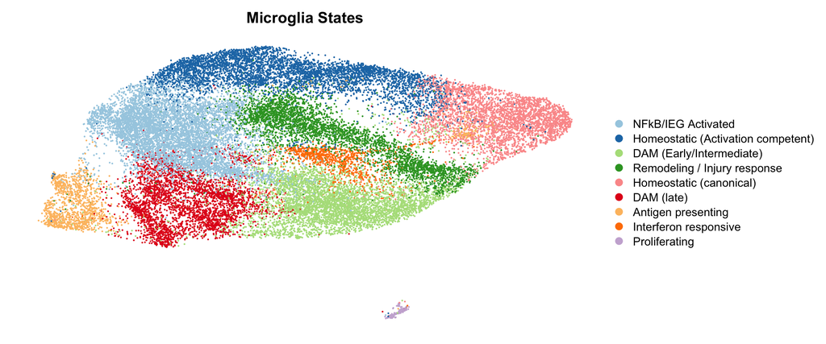

## 9.2 Total cells

Bar plot showing the number of cells assigned to each cluster.

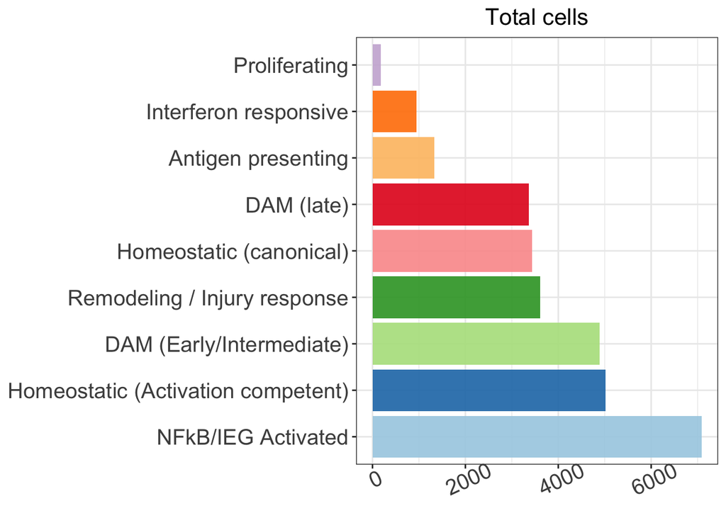

## 9.3 Gene Heatmap & hierarchical cluster

Heatmap of normalized expression levels for representative marker genes across clusters, with hierarchical clustering applied to both genes and clusters, providing an overview of the molecular signatures that distinguish microglial states.

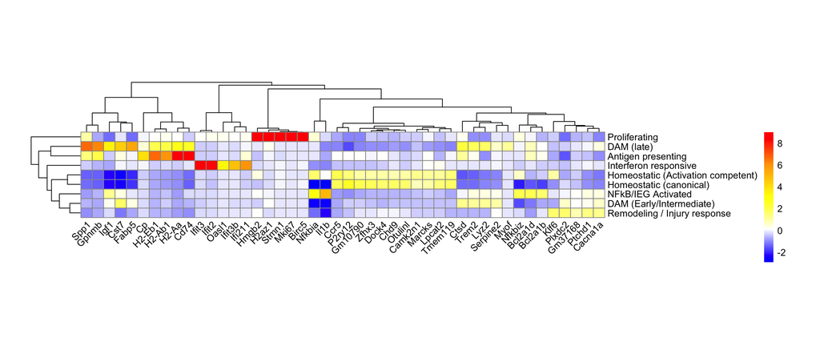

## 9.4 Proportions (%) of Microglial States Across Samples and Treatments

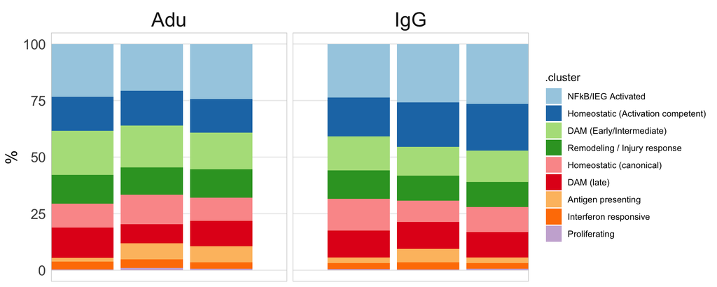

Stacked barplot of the relative abundance of each microglial Seurat-defined cluster in individual samples and compared proportions between the Aducanumab-treated and IgG control groups.

|  | Adu | IgG | p.overall |
| --- | --- | --- | --- |
|  | N=3 | N=3 |  |
| NFkB/IEG Activated | 23.3 [22.0;23.8] | 25.9 [24.8;26.1] | 0.127 |
| Homeostatic (Activation competent) | 14.9 [14.9;15.1] | 19.6 [18.5;20.1] | 0.050 |
| DAM (Early/Intermediate) | 18.5 [17.4;19.0] | 13.9 [13.3;14.4] | 0.050 |
| Remodeling / Injury response | 12.5 [12.3;12.6] | 11.1 [11.1;11.8] | 0.268 |
| Homeostatic (canonical) | 10.6 [10.4;11.8] | 11.1 [10.2;12.6] | 0.827 |
| DAM (late) | 11.2 [9.80;12.3] | 11.8 [11.5;11.9] | 0.658 |
| Antigen presenting | 7.10 [4.30;7.10] | 2.40 [2.40;4.20] | 0.500 |
| Interferon responsive | 3.60 [3.25;3.70] | 2.70 [2.65;2.90] | 0.127 |
| Proliferating | 0.60 [0.45;0.80] | 0.50 [0.45;0.55] | 0.658 |

Values are median % of microglia in that cluster per sample, with IQR.  
p.overall: Mann-Whitney p-value

## 9.5 Probability that a given cell belongs to the specific target cluster

To quantify changes in microglial cell state composition between Aducanumab-treated and IgG-treated groups, we performed a differential abundance analysis using a generalized linear mixed model (GLMM) framework. We implemented this analysis in R using the lme4 package, treating cellular identity as a binary outcome in a series of “one-vs-rest” logistic regressions for each cluster. The treatment condition served as the fixed effect, while the biological replicate (Mouse ID) was included as a random intercept to account for baseline variability between animals. We calculated the Odds Ratio (OR) and 95% Confidence Interval (CI) from the model coefficients to estimate the magnitude and precision of the treatment effect. Significance was assessed using the Wald Z-test, and results were visualized as a forest plot

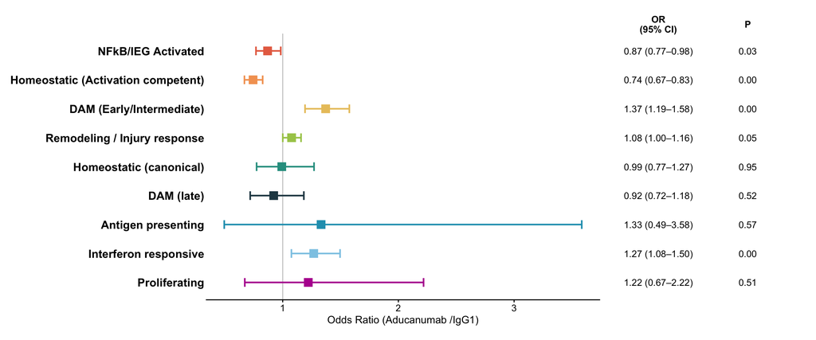

Aducanumab treatment induced distinct shifts in the proportional abundance of specific microglial states compared to IgG controls. We observed a significant expansion of the “DAM (Early/Intermediate)” population (OR = 1.37, 95% CI: 1.19–1.58, P < 0.01) and the “Interferon responsive” cluster (OR = 1.27, 95% CI: 1.08–1.50, P < 0.01), suggesting a drug-induced transition toward reactive phenotypes. Conversely, this expansion was mirrored by a significant reduction in the “Homeostatic (Activation competent)” state (OR = 0.74, 95% CI: 0.67–0.83, P < 0.01) and the “NFkB/IEG Activated” state (OR = 0.87, 95% CI: 0.77–0.98, P = 0.03). The “Remodeling / Injury response” cluster showed a borderline increase (P = 0.05), while canonical homeostatic microglia, antigen-presenting cells, late-stage DAMs, and proliferating cells remained stable with no statistically significant differences between treatment groups.

## 9.6 Module scores

UMAP displaying the combined expression scores or the distribution of individual canonical microglial marker genes, illustrating the transcriptional features that define each cluster.

Markers from bibliography to generate the scores

| Signature | genes |
| --- | --- |
| AP | Cd74, B2m, Cd37, Lgals1, Rpl26, Rps19, Rps8, Rps4x, Rps15a, H2-Eb1, H2-Ab1, H2-Aa |
| CRM | Il1b, Ch25h, Padi2, Plek, Tlr2, Junb, C3ar1, Nfkbia, Trem2, Tyrobp |
| DAM | Spp1, Lipa, Apoc1, Ccl3, Fabp5, Trem2, Cxcr4, Gpnmb, Litaf, Cstb, Rps18, Rpl11, Rpl37a, Axl, Dbi |
| Homeostatic | P2ry13, P2ry12, Cx3cr1, Cst3, Ltc4s, Bin1, Maf, Frmd4a, Csf1r, C1qa, Dock8, Stab1, Sparc |
| IRM | Ifit2, Il1b, Epsti1, Eif2ak2, Bst2, Tnfsf10, Sp110, Irf1, Tap1, Adar, Cd48, Nampt |
| TIM | Klf4, Malat1, Tmx4, Jund, Btg2, Jun, Fos, Klf2 |

Red dots indicate cells with high signature scores (**top 25%**), while grey represents cells with lower scores

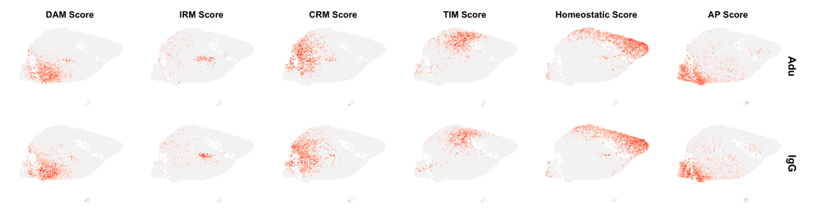

Homeostatic  
DAM: Disease associated microglia  
AP : Antigen Presenting (HLA/MHC class II)  
IRM : Interferon-response microglia.  
CRM : Cytokine-Response microglia Markers described in (Fumagalli et al. 2025)

TIM : Terminally inflammatory microglia (Millet, Ledo, and Tavazoie 2024)

## 9.7 Microglia states according to (Fumagalli et al. 2025)

Using `AddModuleScore` in the previous step, each cell received a numerical score for each signature.  
Then, for each cell, the maximum score across all signatures was identified, and the corresponding label was assigned as its “dominant phenotype.” This categorical assignment was stored in the metadata under the identity class `score_cluster`.

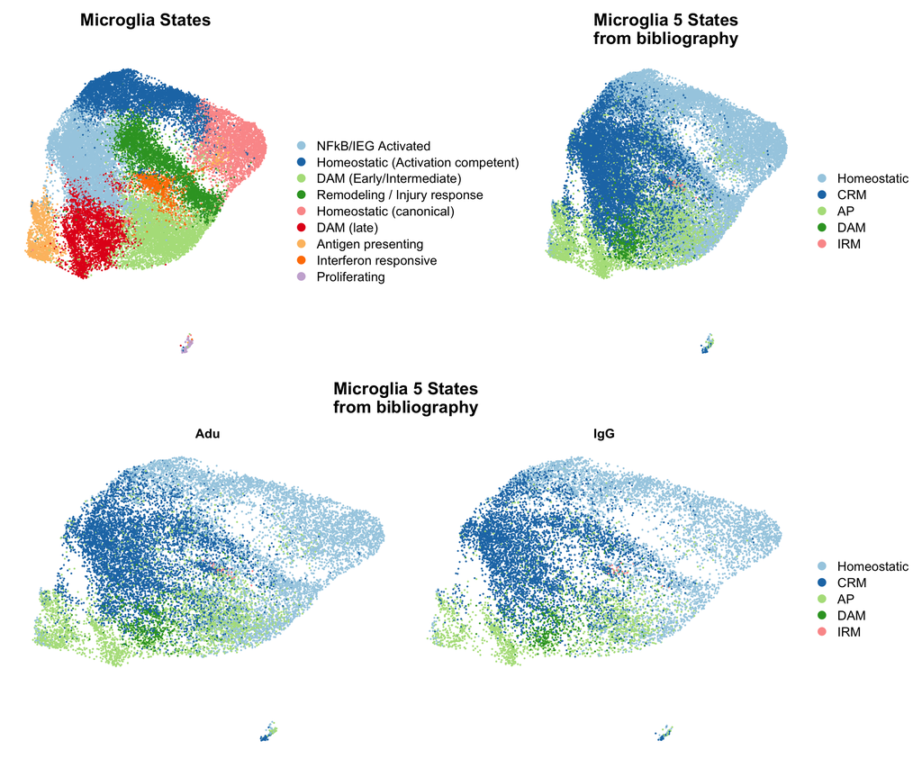

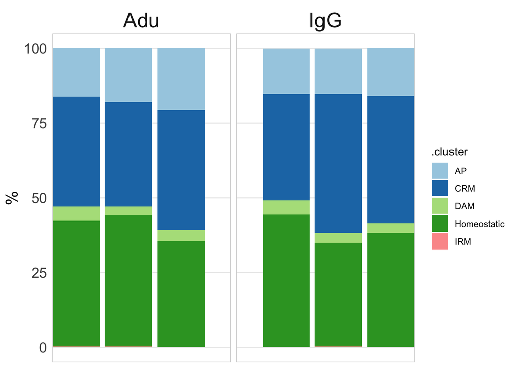

Summary descriptives table by groups of `Treatment.Group'

|  | Adu | IgG | p.overall |
| --- | --- | --- | --- |
|  | N=3 | N=3 |  |
| AP | 17.9 [17.0;19.2] | 15.1 [15.1;15.4] | 0.046 |
| CRM | 36.8 [35.9;38.5] | 42.6 [39.1;44.5] | 0.275 |
| DAM | 3.60 [3.25;4.20] | 3.40 [3.30;4.10] | 1.000 |
| Homeostatic | 42.0 [38.8;43.0] | 38.2 [36.5;41.2] | 0.827 |
| IRM | 0.30 [0.20;0.30] | 0.20 [0.15;0.25] | 0.637 |

Fumagalli, Laura, Alma Nazlie Mohebiany, Jessie Premereur, Paula Polanco Miquel, Baukje Bijnens, Pieter Van de Walle, Nicola Fattorelli, and Renzo Mancuso. 2025. “Microglia Heterogeneity, Modeling and Cell-State Annotation in Development and Neurodegeneration.” *Nature Neuroscience* 28 (7): 1381–92. https://doi.org/10.1038/s41593-025-01931-4.

Millet, Alon, Jose Henrique Ledo, and Sohail F. Tavazoie. 2024. “An Exhausted-Like Microglial Population Accumulates in Aged and APOE4 Genotype Alzheimer’s Brains.” *Immunity* 57 (1): 153–170.e6. https://doi.org/10.1016/j.immuni.2023.12.001.